# TBM

Mostafa Kamal

2023-06-18

### loading the data

```r
# library()

library(readxl)
library(tidyverse)
library(stargazer)
```

```r
library(ggplot2)
library(plm)
library(urca)
# loading the data and grooming the data
data <- read_excel("Data for analysis.xlsx",
                                        sheet = "Final",
                                        col_types = c(rep("text",5), rep('numeric',32)))
data <- as.data.frame(na.omit(data))
```

### Preparing the initial graphs

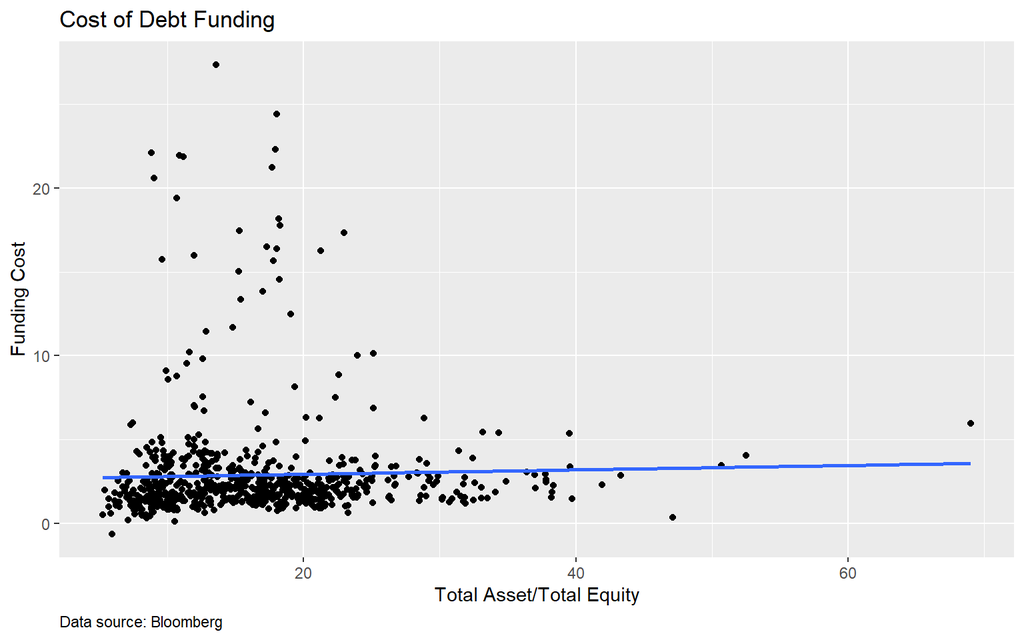

```r
# 1st one ------------------------------------------------------------------------

# for all

data %>%
  #group_by(countryOfOrigin) %>%
  ggplot(mapping = aes(x=TA_TE, y=FundingCost))+
  geom_point()+
  geom_smooth(method = 'lm', se=FALSE)+
  #facet_wrap(facets = ~countryOfOrigin, scales = 'free_y', ncol = 2)+
  labs(title = "Cost of Debt Funding",
       # subtitle = "Categories are based on bank regions",
       caption = "Data source: Bloomberg") +
  xlab('Total Asset/Total Equity') + ylab('Funding Cost')+
  theme(legend.position = 'none',
        plot.caption = element_text(hjust = 0))
```

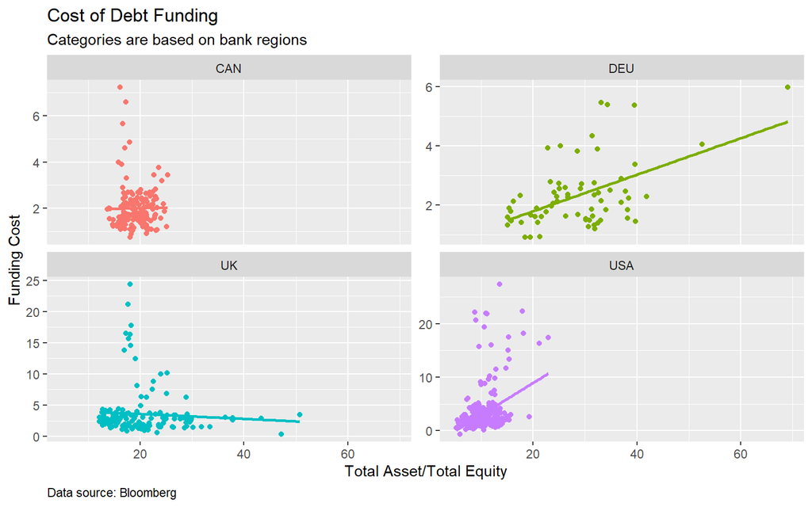

```r
# for country wise

data %>%
  group_by(countryOfOrigin) %>%
  ggplot(mapping = aes(x=TA_TE, y=FundingCost,col=countryOfOrigin))+
  geom_point()+
  geom_smooth(method = 'lm', se=FALSE)+
  facet_wrap(facets = ~countryOfOrigin, scales = 'free_y', ncol = 2)+
  labs(title = "Cost of Debt Funding",
       subtitle = "Categories are based on bank regions",
       caption = "Data source: Bloomberg") +
  xlab('Total Asset/Total Equity') + ylab('Funding Cost')+
  theme(legend.position = 'none',
        plot.caption = element_text(hjust = 0))
```

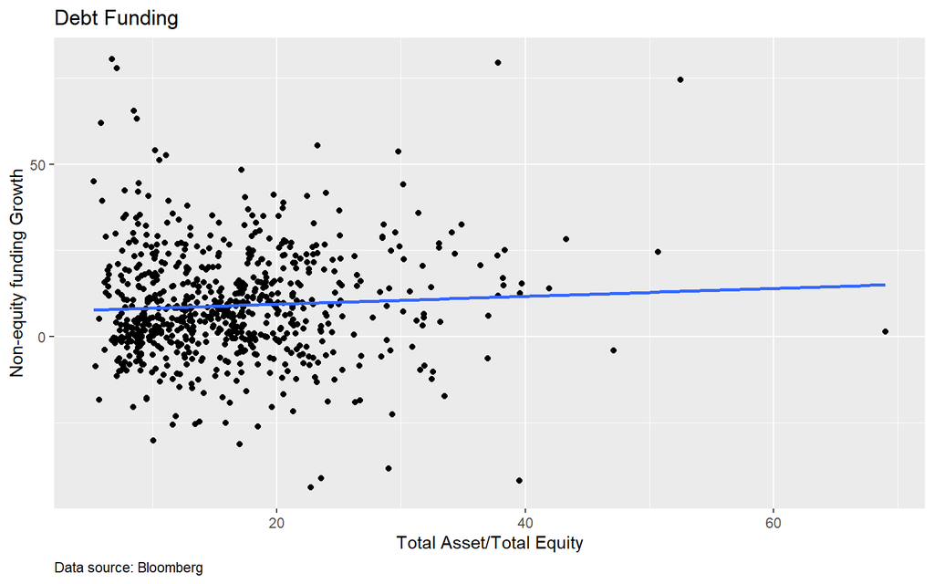

```r
# 2nd one ------------------------------------------------------------------------

# for all

data %>%
  # group_by(countryOfOrigin) %>%
  ggplot(mapping = aes(x=TA_TE, y=TFundGrow))+
  geom_point()+
  geom_smooth(method = 'lm', se=FALSE)+
  # facet_wrap(facets = ~countryOfOrigin, scales = 'free_y', ncol = 2)+
  labs(title = "Debt Funding",
       # subtitle = "Categories are based on bank regions",
       caption = "Data source: Bloomberg") +
  xlab('Total Asset/Total Equity') + ylab('Non-equity funding Growth')+
  theme(legend.position = 'none',
        plot.caption = element_text(hjust = 0))
```

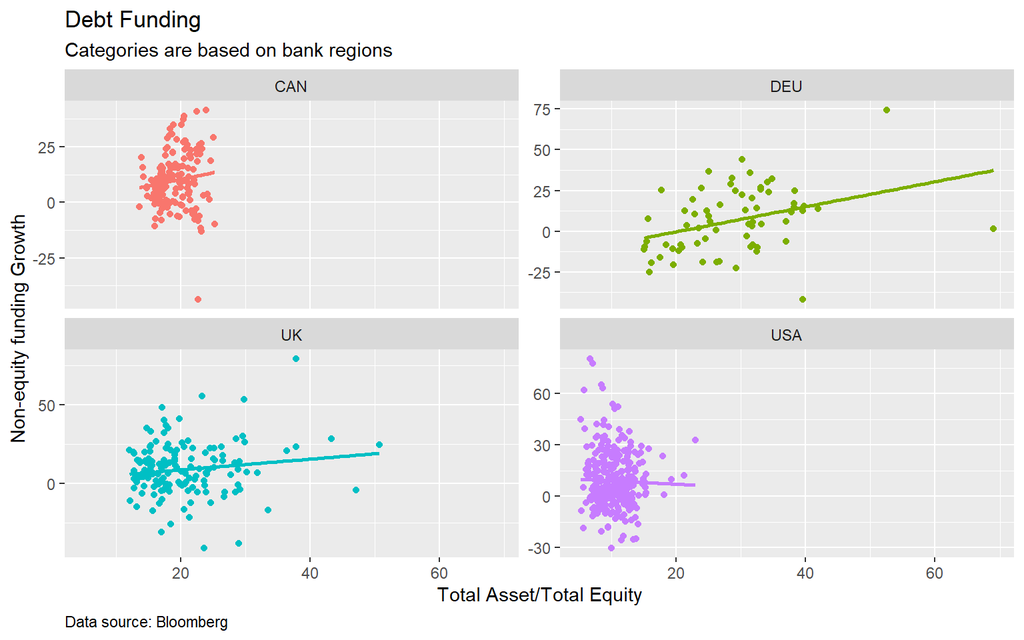

```r
# for country wise

data %>%
  group_by(countryOfOrigin) %>%
  ggplot(mapping = aes(x=TA_TE, y=TFundGrow,col=countryOfOrigin))+
  geom_point()+
  geom_smooth(method = 'lm', se=FALSE)+
  facet_wrap(facets = ~countryOfOrigin, scales = 'free_y', ncol = 2)+
  labs(title = "Debt Funding",
       subtitle = "Categories are based on bank regions",
       caption = "Data source: Bloomberg") +
  xlab('Total Asset/Total Equity') + ylab('Non-equity funding Growth')+
  theme(legend.position = 'none',
        plot.caption = element_text(hjust = 0))
```

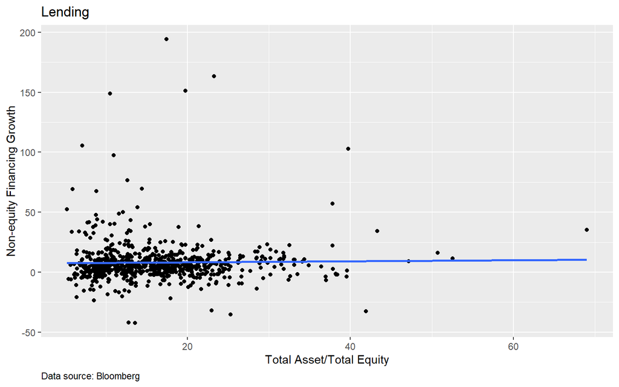

```r
# 3rd ----------------------------------------------------------------------------

# for all()

data %>%
  # group_by(countryOfOrigin) %>%
  ggplot(mapping = aes(x=TA_TE, y=LG))+
  geom_point()+
  geom_smooth(method = 'lm', se=FALSE)+
  # facet_wrap(facets = ~countryOfOrigin, scales = 'free_y', ncol = 2)+
  labs(title = "Lending",
       # subtitle = "Categories are based on bank regions",
       caption = "Data source: Bloomberg") +
  xlab('Total Asset/Total Equity') + ylab('Non-equity Financing Growth')+
  theme(legend.position = 'none',
        plot.caption = element_text(hjust = 0))
```

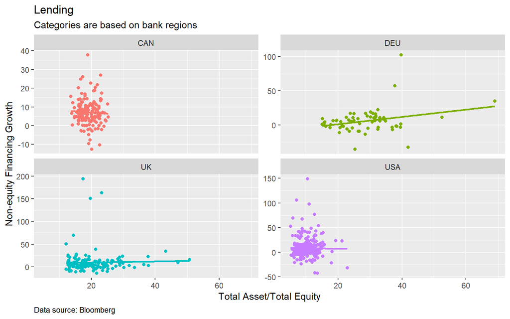

```r
# for country wise

data %>%
  group_by(countryOfOrigin) %>%
  ggplot(mapping = aes(x=TA_TE, y=LG,col=countryOfOrigin))+
  geom_point()+
  geom_smooth(method = 'lm', se=FALSE)+
  facet_wrap(facets = ~countryOfOrigin, scales = 'free_y', ncol = 2)+
  labs(title = "Lending",
       subtitle = "Categories are based on bank regions",
       caption = "Data source: Bloomberg") +
  xlab('Total Asset/Total Equity') + ylab('Non-equity Financing Growth')+
  theme(legend.position = 'none',
        plot.caption = element_text(hjust = 0))
```

### Summary statistics

```r
# High Levered and low levered banks and their summary stats

# summary statistics for the banks (need to add all the variables)

leverdUnleverd <- data %>%
  group_by(bankName) %>%
  summarise(
    N = n(),
    Min = min(TA_TE),
    Mean = mean(TA_TE),
    q1 = quantile(TA_TE,probs = 0.25),
    Median = median(TA_TE),
    q3 = quantile(TA_TE,probs = 0.75),
    Max = max(TA_TE))



# 1st and 4th quantile of the overall asset/equity

data %>%
  summarise(
    quantile = quantile(TA_TE, probs = c(0.25,0.75))
  )
```

```
##   quantile
## 1  10.1107
## 2  20.1072
```

```r
# finding the levered and unlevered firms

leverdUnleverd %>%
  filter(q1<=10.11 | q1>=20.12) %>%
  arrange(q1)
```

```
## # A tibble: 14 × 8
##    bankName                    N   Min  Mean    q1 Median    q3   Max
##    <chr>                   <int> <dbl> <dbl> <dbl>  <dbl> <dbl> <dbl>
##  1 Santander Holdings         24  5.23  8.88  6.33   8.40 11.8  13.9
##  2 Capial One Financial       24  5.82  7.27  6.65   7.11  7.67  9.63
##  3 Truist Financial           24  7.11  9.26  7.68   9.21 10.4  13.0
##  4 M&T Bank                   24  7.30  8.85  7.82   8.69  9.46 12.5
##  5 PNC                        24  7.27  8.92  7.96   8.53 10.0  12.2
##  6 Fifth Third Bancorp        24  7.88  9.47  8.82   8.95 10.1  12.1
##  7 Bank of New York Mellon    24  6.72  9.72  8.90   9.83 10.3  12.8
##  8 KeyCorp                    24  8.07 10.6   8.94   9.72 12.5  14.1
##  9 Bank of America            24  8.22 10.7   9.15  10.3  11.9  15.0
## 10 US Bancorp                 24  8.71 10.0   9.30  10.0  10.4  13.2
## 11 Citigroup Inc              24  7.76 11.6   9.75  11.7  12.7  19.3
## 12 Commerzbank                34 15.1  28.0  20.5   30.8  32.6  41.9
## 13 Barclays                   34 17.0  24.6  20.5   23.6  26.8  43.3
## 14 Deutsche Bank              33 18.5  29.6  23.3   26.2  33.1  69.0
```

```r
# partioning the data in the highly levered and lower levered dataset

dataHL <- data %>%
  # select(bankName, Year, LL, HL) %>%
  mutate(
    LL = case_when(
      bankName== "Santander Holdings"~1,
      bankName== "Capial One Financial"~1,
      bankName== "Truist Financial"~1,
      bankName== "M&T Bank"~1,
      bankName== "PNC"~1,
      bankName== "Fifth Third Bancorp"~1,
      bankName== "Bank of New York Mellon"~1,
      bankName== "KeyCorp"~1,
      bankName== "Bank of America"~1,
      bankName== "US Bancorp"~1,
      bankName== "Citigroup Inc"~1,
      TRUE ~ 0),
    HL = case_when(
      bankName== "Barclays"~1,
      bankName== "Commerzbank"~1,
      bankName== "Deutsche Bank"~1,
      TRUE ~ 0))

dataHL %>%
  # group_by(LL,HL) %>%
  filter(HL==1 | LL==1) %>%
  group_by(LL,HL) %>%
  summarise(
    obs=n(),
    assets=mean(TA/1000),
    costOfDebtFinancing = mean(FundingCost),
    growthRateOfDebtFinancing =mean(TFundGrow),
    growthRateOfLending = mean(LG),
    assetRisk = sd(TA/1000),
    ROA = mean(ROA))%>%
  t() %>%
  round(digits = 3)
```

[output not shown]

```
##                               [,1]    [,2]
## LL                           0.000   1.000
## HL                           1.000   0.000
## obs                        101.000 264.000
## assets                    1037.813 479.356
## costOfDebtFinancing          2.276   2.083
## growthRateOfDebtFinancing    7.266   9.364
## growthRateOfLending          5.856   8.222
## assetRisk                  803.587 682.449
## ROA                          0.223   1.112
```

```r
# summary statistics for all the variables

summData <- as.matrix(data[,6:dim(data)[2]]) # just numeric variables
summaryResults <- list()

allMin <- apply(summData, MARGIN = 2, FUN = min, na.rm=TRUE)
allMean <- apply(summData, MARGIN = 2, FUN = mean, na.rm=TRUE)
allMax <- apply(summData, MARGIN = 2, FUN = max, na.rm=TRUE)
allSD <- apply(summData, MARGIN = 2, FUN = sd, na.rm=TRUE)
allCorr <- round(cor(summData[,-c(1:4)]),digits = 4) # maybe a heatmap
summaryResults$All <- round(data.frame(allMin,allMean,allMax,allSD), digits = 3)
```

### Need to calculate panel wise summary (country and year wise)

### Book of envelop calc and their figures

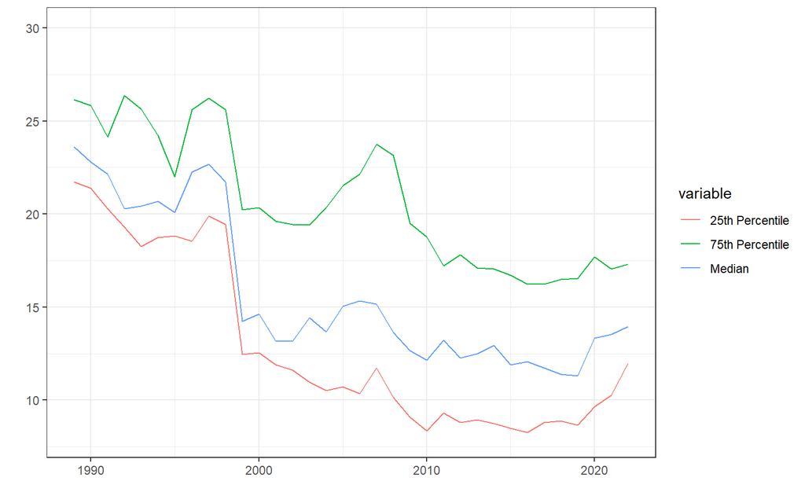

```r
# Asset and total equity (i)

dataFig <- data
dataFig$year <- as.numeric(dataFig$year)

dataFig %>%
  group_by(year) %>%
  summarise(
    `Median`=median(TA_TE),
    `25th Percentile` = quantile(TA_TE, probs = 0.25),
    `75th Percentile` = quantile(TA_TE, probs = 0.75)
  ) %>%
  ungroup() %>%
  pivot_longer(cols = -year,names_to = "variable",values_to = "value") %>%
  ggplot(mapping = aes(x=year, y=value, col=variable))+
  geom_line()+
  ylim(c(8,30))+
  theme_bw()+
  xlab('')+
  ylab('')
```

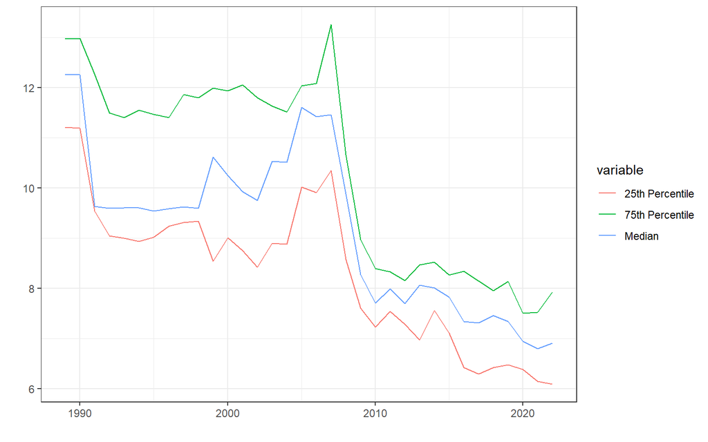

```r
# RWA and TierCap (i)

dataFig %>%
  group_by(year) %>%
  summarise(
    `Median`=median(RWA_TierCap),
    `25th Percentile` = quantile(RWA_TierCap, probs = 0.25),
    `75th Percentile` = quantile(RWA_TierCap, probs = 0.75)
  ) %>%
  ungroup() %>%
  pivot_longer(cols = -year,names_to = "variable",values_to = "value") %>%
  ggplot(mapping = aes(x=year, y=value, col=variable))+
  geom_line()+
  theme_bw()+
  xlab('')+
  ylab('')
```

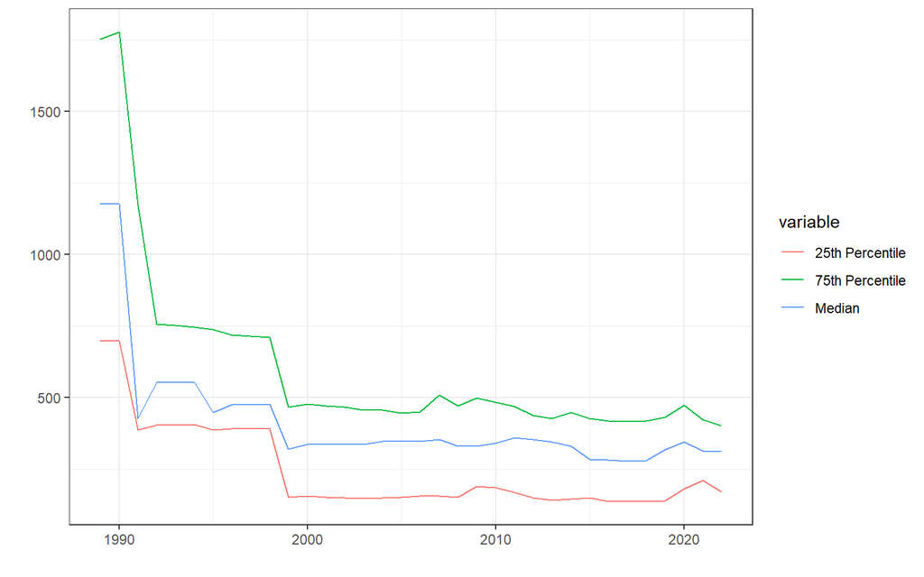

```r
# Total fair value of the asset and the market value of the equity (need the market value of equity) (iv)

dataFig %>%
  group_by(year) %>%
  summarise(
    `Median`=median(FVA_TCE),
    `25th Percentile` = quantile(FVA_TCE, probs = 0.25),
    `75th Percentile` = quantile(FVA_TCE, probs = 0.75)
  ) %>%
  ungroup() %>%
  pivot_longer(cols = -year,names_to = "variable",values_to = "value") %>%
  ggplot(mapping = aes(x=year, y=value, col=variable))+
  geom_line()+
  theme_bw()+
  xlab('')+
  ylab('')
```

## Regression analysis

### Proposition 1: Elasticity of bank activity with respect to bank capital

```r
# model results

q1modeli <- plm(formula = log(TA)~log(TCE),model = 'within',data = data)
q1modelii <- plm(formula = log(TA)~log(TCE)+ROA,model = 'within',data = data)
q1modeliii <- plm(formula = log(TA)~log(TCE)+ROA,model = 'within',index = c('bankID'), data = data)
q1modeliv <- plm(formula = log(TA)~log(TCE)+ROA,model = 'within',index = c('bankID','year'),data = data)
q1modelv <- plm(formula = log(TA)~log(TCE)+ROA,model = 'within',effect = 'twoways',index = c('bankID','year'),data = data)


# compiling the results
result1 <- stargazer(q1modeli,q1modelii,q1modeliii,q1modeliv,q1modelv, type = 'text',
          omit.summary.stat = 'mean',header = FALSE,
          digits = 3)
```

```
##
## =================================================================================================================================================
##                                                                      Dependent variable:
##              ------------------------------------------------------------------------------------------------------------------------------------
##                                                                            log(TA)
##                         (1)                        (2)                        (3)                        (4)                       (5)
## -------------------------------------------------------------------------------------------------------------------------------------------------
## log(TCE)              1.050***                   1.024***                   0.868***                   0.868***                  0.760***
##                       (0.018)                    (0.015)                    (0.009)                    (0.009)                   (0.024)
##
## ROA                                             -0.421***                  -0.088***                  -0.088***                 -0.066***
##                                                  (0.025)                    (0.015)                    (0.015)                   (0.016)
##
## -------------------------------------------------------------------------------------------------------------------------------------------------
## Observations            709                        709                        709                        709                       709
## R2                     0.831                      0.881                      0.936                      0.936                     0.620
## Adjusted R2            0.823                      0.875                      0.933                      0.933                     0.585
## F Statistic  3,318.591*** (df = 1; 674) 2,490.432*** (df = 2; 673) 4,957.591*** (df = 2; 681) 4,957.591*** (df = 2; 681) 528.224*** (df = 2; 648)
## =================================================================================================================================================
## Note:                                                                                                                 *p<0.1; **p<0.05; ***p<0.01
```

```r
result1
```

```
##  [1] ""
##  [2] "================================================================================================================================================="
##  [3] "                                                                     Dependent variable:                                                         "
##  [4] "             ------------------------------------------------------------------------------------------------------------------------------------"
##  [5] "                                                                           log(TA)                                                               "
##  [6] "                        (1)                        (2)                        (3)                        (4)                       (5)           "
##  [7] "-------------------------------------------------------------------------------------------------------------------------------------------------"
##  [8] "log(TCE)              1.050***                   1.024***                   0.868***                   0.868***                  0.760***        "
##  [9] "                      (0.018)                    (0.015)                    (0.009)                    (0.009)                   (0.024)         "
## [10] "                                                                                                                                                 "
## [11] "ROA                                             -0.421***                  -0.088***                  -0.088***                 -0.066***        "
## [12] "                                                 (0.025)                    (0.015)                    (0.015)                   (0.016)         "
## [13] "                                                                                                                                                 "
## [14] "-------------------------------------------------------------------------------------------------------------------------------------------------"
## [15] "Observations            709                        709                        709                        709                       709           "
## [16] "R2                     0.831                      0.881                      0.936                      0.936                     0.620          "
## [17] "Adjusted R2            0.823                      0.875                      0.933                      0.933                     0.585          "
## [18] "F Statistic  3,318.591*** (df = 1; 674) 2,490.432*** (df = 2; 673) 4,957.591*** (df = 2; 681) 4,957.591*** (df = 2; 681) 528.224*** (df = 2; 648)"
## [19] "================================================================================================================================================="
## [20] "Note:                                                                                                                 *p<0.1; **p<0.05; ***p<0.01"
```

```r
# coeftest
lmtest::coeftest(q1modeli,vcovHC(q1modeli,type = 'HC0',cluster = 'group'))
```

```
##
## t test of coefficients:
##
##          Estimate Std. Error t value  Pr(>|t|)
## log(TCE) 1.049714   0.006856  153.11 < 2.2e-16 ***
## ---
## Signif. codes:  0 '***' 0.001 '**' 0.01 '*' 0.05 '.' 0.1 ' ' 1
```

```r
# serial correlation method
pbgtest(q1modeli,order = 1)
```

```
##
##  Breusch-Godfrey/Wooldridge test for serial correlation in panel models
##
## data:  log(TA) ~ log(TCE)
## chisq = 150.23, df = 1, p-value < 2.2e-16
## alternative hypothesis: serial correlation in idiosyncratic errors
```

```r
pbgtest(q1modelii,order = 1)
```

```
##
##  Breusch-Godfrey/Wooldridge test for serial correlation in panel models
##
## data:  log(TA) ~ log(TCE) + ROA
## chisq = 97.914, df = 1, p-value < 2.2e-16
## alternative hypothesis: serial correlation in idiosyncratic errors
```

```r
pbgtest(q1modeliii,order = 1)
```

```
##
##  Breusch-Godfrey/Wooldridge test for serial correlation in panel models
##
## data:  log(TA) ~ log(TCE) + ROA
## chisq = 405.07, df = 1, p-value < 2.2e-16
## alternative hypothesis: serial correlation in idiosyncratic errors
```

```r
pbgtest(q1modeliv,order = 1)
```

```
##
##  Breusch-Godfrey/Wooldridge test for serial correlation in panel models
##
## data:  log(TA) ~ log(TCE) + ROA
## chisq = 405.07, df = 1, p-value < 2.2e-16
## alternative hypothesis: serial correlation in idiosyncratic errors
```

```r
pbgtest(q1modelv,order = 1)
```

```
##
##  Breusch-Godfrey/Wooldridge test for serial correlation in panel models
##
## data:  log(TA) ~ log(TCE) + ROA
## chisq = 418.59, df = 1, p-value < 2.2e-16
## alternative hypothesis: serial correlation in idiosyncratic errors
```

### Proposition 2: How does equity react to changes in the business and financial cycle?

- growth rate of common equity == gdp growth+lag(common equity growth)+ROA+IFRS, index=(‘bankID’) ——(i)
- growth rate of common equity == stock market growth + lag(common equity growth)+ROA+IFRS, index=(‘bankID’)——(ii)
- growth rate of common equity == gdp growth:crisis_II+lag(common equity growth)+ROA+IFRS, index=(‘bankID’) ——(iii)
- growth rate of common equity == stock market growth:crisis_II+lag(common equity growth)+ROA+IFRS, index=(‘bankID’) ——(iv)
- growth rate of Tier 1 capital == gdp growth+lag( growth rate of Tier 1 capita)+ROA+IFRS, index=(‘bankID’) ——(i)
- growth rate of Tier 1 capital == stock market growth +lag( growth rate of Tier 1 capita)+ROA+IFRS, index=(‘bankID’) ——(ii)
- growth rate of Tier 1 capital == gdp growth:crisis_II + lag( growth rate of Tier 1 capita)+ROA+IFRS, index=(‘bankID’)——(iii)
- growth rate of Tier 1 capital == stock market growth:crisis_II +lag( growth rate of Tier 1 capita)+ROA+IFRS, index=(‘bankID’) ——(iv)

```r
# models

q2_1modeli <- plm(formula = TCEG~lag(TCEG)+GDPGrowth+ROA+IFRS,
                  index = 'bankID',model = 'within',data = data)

q2_1modelii <- plm(formula = TCEG~lag(TCEG)+SMGSnP500+ROA+IFRS,
                   index = 'bankID',model = 'within',data = data)

q2_1modeliii <- plm(formula = TCEG~lag(TCEG)+GDPGrowth:crisisGfc+ROA+IFRS,
                    index = 'bankID',model = 'within',data = data)

q2_1modeliv <- plm(formula = TCEG~lag(TCEG)+SMGSnP500:crisisGfc+ROA+IFRS,
                   index = 'bankID',model = 'within',data = data)

# results

stargazer(q2_1modeli,q2_1modelii,q2_1modeliii,q2_1modeliv, type = 'text',
          omit.summary.stat = 'mean',
          digits=3)
```

```
##
## =================================================================
##                                     Dependent variable:
##                           ---------------------------------------
##                                            TCEG
##                              (1)       (2)       (3)       (4)
## -----------------------------------------------------------------
## lag(TCEG)                 -0.075**  -0.078**   -0.071*  -0.077**
##                            (0.037)   (0.038)   (0.040)   (0.039)
##
## GDPGrowth                 -1.045***
##                            (0.335)
##
## SMGSnP500                            -0.080*
##                                      (0.044)
##
## ROA                       11.498*** 10.466*** 9.980***  10.138***
##                            (1.345)   (1.289)   (1.262)   (1.293)
##
## GDPGrowth:crisisGfc                            -0.559
##                                                (0.626)
##
## SMGSnP500:crisisGfc                                      -0.045
##                                                          (0.076)
##
## -----------------------------------------------------------------
## Observations                 683       683       683       683
## R2                          0.101     0.093     0.089     0.089
## Adjusted R2                 0.063     0.054     0.050     0.050
## F Statistic (df = 3; 654) 24.609*** 22.251*** 21.340*** 21.175***
## =================================================================
## Note:                                 *p<0.1; **p<0.05; ***p<0.01
```

```r
# serial correlatio test

pbgtest(q2_1modeli,order = 1)
```

```
##
##  Breusch-Godfrey/Wooldridge test for serial correlation in panel models
##
## data:  TCEG ~ lag(TCEG) + GDPGrowth + ROA + IFRS
## chisq = 0.55413, df = 1, p-value = 0.4566
## alternative hypothesis: serial correlation in idiosyncratic errors
```

```r
pbgtest(q2_1modelii,order = 1)
```

```
##
##  Breusch-Godfrey/Wooldridge test for serial correlation in panel models
##
## data:  TCEG ~ lag(TCEG) + SMGSnP500 + ROA + IFRS
## chisq = 0.54183, df = 1, p-value = 0.4617
## alternative hypothesis: serial correlation in idiosyncratic errors
```

```r
pbgtest(q2_1modeliii,order = 1)
```

```
##
##  Breusch-Godfrey/Wooldridge test for serial correlation in panel models
##
## data:  TCEG ~ lag(TCEG) + GDPGrowth:crisisGfc + ROA + IFRS
## chisq = 0.0090727, df = 1, p-value = 0.9241
## alternative hypothesis: serial correlation in idiosyncratic errors
```

```r
pbgtest(q2_1modeliv,order = 1)
```

```
##
##  Breusch-Godfrey/Wooldridge test for serial correlation in panel models
##
## data:  TCEG ~ lag(TCEG) + SMGSnP500:crisisGfc + ROA + IFRS
## chisq = 0.0047951, df = 1, p-value = 0.9448
## alternative hypothesis: serial correlation in idiosyncratic errors
```

```r
# 2nd part -----------------------------------------------------------------------


# Models


q2_2modeli <- plm(formula = TierCapGrowth~lag(TierCapGrowth)+GDPGrowth+ROA+IFRS,
                  index = 'bankID',model = 'within',data = data)

q2_2modelii <- plm(formula = TierCapGrowth~lag(TierCapGrowth)+SMGSnP500+ROA+IFRS,
                   index = 'bankID',model = 'within',data = data)

q2_2modeliii <- plm(formula = TierCapGrowth~lag(TierCapGrowth)+GDPGrowth:crisisGfc+ROA+IFRS,
                    index = 'bankID',model = 'within',data = data)

q2_2modeliv <- plm(formula = TierCapGrowth~lag(TierCapGrowth)+SMGSnP500:crisisGfc+ROA+IFRS,
                   index = 'bankID',model = 'within',data = data)


# results

stargazer(q2_2modeli,q2_2modelii,q2_2modeliii,q2_2modeliv, type = 'text',
          omit.summary.stat = 'mean',
          digits = 3)
```

```
##
## =================================================================
##                                     Dependent variable:
##                           ---------------------------------------
##                                        TierCapGrowth
##                              (1)       (2)       (3)       (4)
## -----------------------------------------------------------------
## lag(TierCapGrowth)        -0.214*** -0.204*** -0.200*** -0.202***
##                            (0.037)   (0.038)   (0.038)   (0.037)
##
## GDPGrowth                 -1.736***
##                            (0.361)
##
## SMGSnP500                           -0.116**
##                                      (0.048)
##
## ROA                        3.265**    1.445     0.647     1.542
##                            (1.436)   (1.386)   (1.361)   (1.394)
##
## GDPGrowth:crisisGfc                             0.596
##                                                (0.647)
##
## SMGSnP500:crisisGfc                                     -0.196**
##                                                          (0.080)
##
## -----------------------------------------------------------------
## Observations                 683       683       683       683
## R2                          0.075     0.051     0.043     0.051
## Adjusted R2                 0.035     0.010     0.003     0.010
## F Statistic (df = 3; 654) 17.681*** 11.648*** 9.913***  11.680***
## =================================================================
## Note:                                 *p<0.1; **p<0.05; ***p<0.01
```

```r
# serial correlation test

pbgtest(q2_2modeli,order = 1)
```

```
##
##  Breusch-Godfrey/Wooldridge test for serial correlation in panel models
##
## data:  TierCapGrowth ~ lag(TierCapGrowth) + GDPGrowth + ROA + IFRS
## chisq = 14.192, df = 1, p-value = 0.0001651
## alternative hypothesis: serial correlation in idiosyncratic errors
```

```r
pbgtest(q2_2modelii,order = 1)
```

```
##
##  Breusch-Godfrey/Wooldridge test for serial correlation in panel models
##
## data:  TierCapGrowth ~ lag(TierCapGrowth) + SMGSnP500 + ROA + IFRS
## chisq = 5.0469, df = 1, p-value = 0.02467
## alternative hypothesis: serial correlation in idiosyncratic errors
```

```r
pbgtest(q2_2modeliii,order = 1)
```

```
##
##  Breusch-Godfrey/Wooldridge test for serial correlation in panel models
##
## data:  TierCapGrowth ~ lag(TierCapGrowth) + GDPGrowth:crisisGfc + ROA +  ...
## chisq = 2.2472, df = 1, p-value = 0.1339
## alternative hypothesis: serial correlation in idiosyncratic errors
```

```r
pbgtest(q2_2modeliv,order = 1)
```

```
##
##  Breusch-Godfrey/Wooldridge test for serial correlation in panel models
##
## data:  TierCapGrowth ~ lag(TierCapGrowth) + SMGSnP500:crisisGfc + ROA +  ...
## chisq = 4.0768, df = 1, p-value = 0.04348
## alternative hypothesis: serial correlation in idiosyncratic errors
```

```r
# Hensen Test is required (to be done)
```

### Proposition 3: Impact of bank capitalisation on funding costs

```r
# without macroVar ---------------------------------------------------------------

q3_1modeli <- plm(formula = FundingCost~lag(FundingCost)+lag(TA_TE)
                  +ROA +factor(IFRS),
                  index = c('bankID','year'),
                  model = 'fd',
                  data = data)

q3_1modelii <- plm(formula = FundingCost~lag(FundingCost)+lag(RWA_TierCap)
                   +ROA+factor(IFRS),
                   index = c('bankID','year'),
                   model = 'fd',data = data)

# 2nd part (with macro variables) -------------------------------------------------


q3_2modeli <- plm(formula = FundingCost~lag(FundingCost)+lag(TA_TE)
                  +GDPGrowth+SMGSnP500
                  +ROA +factor(IFRS),
                  index = c('bankID','year'),
                  model = 'fd',
                  data = data)

q3_2modelii <- plm(formula = FundingCost~lag(FundingCost)+lag(RWA_TierCap)
                   +GDPGrowth+SMGSnP500
                   +ROA+factor(IFRS),
                   index = c('bankID','year'),
                   model = 'fd',data = data)

q3_2modeliii <- plm(formula = FundingCost~lag(FundingCost)+lag((TCE/TA)*100)
                   +GDPGrowth+SMGSnP500
                   +ROA+factor(IFRS),
                   index = c('bankID','year'),
                   model = 'fd',data = data)


stargazer(q3_1modeli, q3_1modelii, q3_2modeli, q3_2modelii, q3_2modeliii,
          type = 'text',
          omit.summary.stat = 'mean',
          digits = 3)
```

```
##
## ==================================================================================================================================
##                                                                  Dependent variable:
##                     --------------------------------------------------------------------------------------------------------------
##                                                                      FundingCost
##                             (1)                  (2)                   (3)                    (4)                    (5)
## ----------------------------------------------------------------------------------------------------------------------------------
## lag(FundingCost)         -0.076**              -0.069*               -0.074*                -0.070*                -0.072*
##                           (0.039)              (0.039)               (0.039)                (0.039)                (0.038)
##
## lag(TA_TE)                -0.005                                      -0.013
##                           (0.018)                                    (0.018)
##
## lag(RWA_TierCap)                                0.057                                        0.041
##                                                (0.040)                                      (0.040)
##
## lag((TCE/TA) * 100)                                                                                                 0.105
##                                                                                                                    (0.065)
##
## GDPGrowth                                                             0.013                  0.013                  0.015
##                                                                      (0.026)                (0.026)                (0.026)
##
## SMGSnP500                                                           -0.012***               -0.011**              -0.013***
##                                                                      (0.004)                (0.004)                (0.004)
##
## ROA                        0.140                0.151                0.238**                0.238**                0.230**
##                           (0.108)              (0.108)               (0.114)                (0.114)                (0.114)
##
## Constant                  -0.062               -0.053                 -0.067                 -0.059                 -0.071
##                           (0.053)              (0.053)               (0.052)                (0.053)                (0.052)
##
## ----------------------------------------------------------------------------------------------------------------------------------
## Observations                655                  655                   655                    655                    655
## R2                         0.009                0.012                 0.024                  0.025                  0.027
## Adjusted R2                0.005                0.008                 0.017                  0.017                  0.020
## F Statistic         2.037 (df = 3; 651) 2.692** (df = 3; 651) 3.217*** (df = 5; 649) 3.320*** (df = 5; 649) 3.639*** (df = 5; 649)
## ==================================================================================================================================
## Note:                                                                                                  *p<0.1; **p<0.05; ***p<0.01
```

```r
pbgtest(q3_1modeli,order = 1)
```

```
##
##  Breusch-Godfrey/Wooldridge test for serial correlation in panel models
##
## data:  FundingCost ~ lag(FundingCost) + lag(TA_TE) + ROA + factor(IFRS)
## chisq = 79.673, df = 1, p-value < 2.2e-16
## alternative hypothesis: serial correlation in idiosyncratic errors
```

```r
pbgtest(q3_1modelii,order = 1)
```

```
##
##  Breusch-Godfrey/Wooldridge test for serial correlation in panel models
##
## data:  FundingCost ~ lag(FundingCost) + lag(RWA_TierCap) + ROA + factor(IFRS)
## chisq = 77.519, df = 1, p-value < 2.2e-16
## alternative hypothesis: serial correlation in idiosyncratic errors
```

```r
pbgtest(q3_2modeli,order = 1)
```

```
##
##  Breusch-Godfrey/Wooldridge test for serial correlation in panel models
##
## data:  FundingCost ~ lag(FundingCost) + lag(TA_TE) + GDPGrowth + SMGSnP500 +  ...
## chisq = 71.897, df = 1, p-value < 2.2e-16
## alternative hypothesis: serial correlation in idiosyncratic errors
```

```r
pbgtest(q3_2modelii,order = 1)
```

```
##
##  Breusch-Godfrey/Wooldridge test for serial correlation in panel models
##
## data:  FundingCost ~ lag(FundingCost) + lag(RWA_TierCap) + GDPGrowth +  ...
## chisq = 71.357, df = 1, p-value < 2.2e-16
## alternative hypothesis: serial correlation in idiosyncratic errors
```

```r
pbgtest(q3_2modeliii,order = 1)
```

```
##
##  Breusch-Godfrey/Wooldridge test for serial correlation in panel models
##
## data:  FundingCost ~ lag(FundingCost) + lag((TCE/TA) * 100) + GDPGrowth +  ...
## chisq = 67.99, df = 1, p-value < 2.2e-16
## alternative hypothesis: serial correlation in idiosyncratic errors
```

### Proposition 4: Do less leveraged banks get more funding?

```r
# without macroVar ---------------------------------------------------------------

q4_1modeli <- plm(formula = TFundGrow~lag(TFundGrow)+lag(TA_TE)+ROA+factor(IFRS),
                  index = c('bankID','year'),
                  model = 'within',
                  data = data)
q4_1modelii <- plm(formula = TFundGrow~lag(TFundGrow)+lag(RWA_TierCap)+ROA+factor(IFRS),
                   index = c('bankID','year'),
                   model = 'within',
                   data = data)

# 2nd part (with macro variables) -------------------------------------------------


q4_2modeli <- plm(formula = TFundGrow~lag(TFundGrow)+lag(TA_TE)
                  +GDPGrowth+SMGSnP500+ROA+factor(IFRS),
                  index = c('bankID','year'),
                  model = 'within',
                  data = data)

q4_2modelii <- plm(formula = TFundGrow~lag(TFundGrow)+lag(RWA_TierCap)
                   +GDPGrowth+SMGSnP500+ROA+factor(IFRS),
                   index = c('bankID','year'),
                   model = 'fd',data = data)

stargazer(q4_1modeli, q4_1modelii, q4_2modeli, q4_2modelii,
          type = 'text',
          omit.summary.stat = 'mean',
          digits = 3)
```

```
##
## ==============================================================================================================
##                                                       Dependent variable:
##                  ---------------------------------------------------------------------------------------------
##                                                            TFundGrow
##                           (1)                     (2)                    (3)                     (4)
## --------------------------------------------------------------------------------------------------------------
## lag(TFundGrow)          0.084**                  0.043                 0.093**                -0.395***
##                         (0.039)                 (0.039)                (0.039)                 (0.035)
##
## lag(TA_TE)               0.031                                          0.010
##                         (0.146)                                        (0.149)
##
## lag(RWA_TierCap)                               1.560***                                         0.743
##                                                 (0.293)                                        (0.567)
##
## GDPGrowth                                                             -1.180***               -1.497***
##                                                                        (0.429)                 (0.370)
##
## SMGSnP500                                                               0.030                 0.196***
##                                                                        (0.058)                 (0.063)
##
## ROA                     5.545***               4.935***                7.096***                 2.406
##                         (1.300)                 (1.278)                (1.393)                 (1.609)
##
## Constant                                                                                       -0.511
##                                                                                                (0.743)
##
## --------------------------------------------------------------------------------------------------------------
## Observations              681                     681                    681                     655
## R2                       0.036                   0.076                  0.049                   0.194
## Adjusted R2              -0.006                  0.036                  0.005                   0.188
## F Statistic      8.023*** (df = 3; 652) 17.833*** (df = 3; 652) 6.716*** (df = 5; 650) 31.232*** (df = 5; 649)
## ==============================================================================================================
## Note:                                                                              *p<0.1; **p<0.05; ***p<0.01
```

```r
pbgtest(q4_1modeli,order = 1)
```

```
##
##  Breusch-Godfrey/Wooldridge test for serial correlation in panel models
##
## data:  TFundGrow ~ lag(TFundGrow) + lag(TA_TE) + ROA + factor(IFRS)
## chisq = 1.3239, df = 1, p-value = 0.2499
## alternative hypothesis: serial correlation in idiosyncratic errors
```

```r
pbgtest(q4_1modelii,order = 1)
```

```
##
##  Breusch-Godfrey/Wooldridge test for serial correlation in panel models
##
## data:  TFundGrow ~ lag(TFundGrow) + lag(RWA_TierCap) + ROA + factor(IFRS)
## chisq = 1.4715, df = 1, p-value = 0.2251
## alternative hypothesis: serial correlation in idiosyncratic errors
```

```r
pbgtest(q4_2modeli,order = 1)
```

```
##
##  Breusch-Godfrey/Wooldridge test for serial correlation in panel models
##
## data:  TFundGrow ~ lag(TFundGrow) + lag(TA_TE) + GDPGrowth + SMGSnP500 +  ...
## chisq = 1.0095, df = 1, p-value = 0.315
## alternative hypothesis: serial correlation in idiosyncratic errors
```

```r
pbgtest(q4_2modelii,order = 1)
```

```
##
##  Breusch-Godfrey/Wooldridge test for serial correlation in panel models
##
## data:  TFundGrow ~ lag(TFundGrow) + lag(RWA_TierCap) + GDPGrowth + SMGSnP500 +  ...
## chisq = 90.914, df = 1, p-value < 2.2e-16
## alternative hypothesis: serial correlation in idiosyncratic errors
```

### Proposition 5: Do less leveraged banks supply more credit?

```r
# without macroVar ---------------------------------------------------------------

q5_1modeli <- plm(formula = LG~lag(LG)+lag(TA_TE)+ROA+factor(IFRS),
                  index = c('bankID','year'),
                  model = 'within',
                  data = data)
q5_1modelii <- plm(formula = LG~lag(LG)+lag(RWA_TierCap)+ROA+factor(IFRS),
                   index = c('bankID','year'),
                   model = 'within',
                   data = data)

# 2nd part (with macro variables) -------------------------------------------------


q5_2modeli <- plm(formula = LG~lag(LG)+lag(TA_TE)+ROA+factor(IFRS)
                  +GDPGrowth+SMGSnP500,
                  index = c('bankID','year'),
                  model = 'within',
                  data = data)

q5_2modelii <- plm(formula = LG~lag(LG)+lag(RWA_TierCap)+ROA+factor(IFRS)
                   +GDPGrowth+SMGSnP500,
                   index = c('bankID','year'),
                   model = 'fd',data = data)

stargazer(q5_1modeli, q5_1modelii, q5_2modeli, q5_2modelii,
          type = 'text',
          omit.summary.stat = 'mean',
          digits = 3)
```

```
##
## ==============================================================================================================
##                                                       Dependent variable:
##                  ---------------------------------------------------------------------------------------------
##                                                               LG
##                            (1)                    (2)                    (3)                     (4)
## --------------------------------------------------------------------------------------------------------------
## lag(LG)                   0.029                  0.020                  0.031                 -0.456***
##                          (0.036)                (0.037)                (0.036)                 (0.034)
##
## lag(TA_TE)              0.545***                                       0.524***
##                          (0.156)                                       (0.160)
##
## lag(RWA_TierCap)                                0.968***                                        0.046
##                                                 (0.324)                                        (0.625)
##
## ROA                     5.604***                5.259***               4.943***                -1.174
##                          (1.404)                (1.412)                (1.517)                 (1.748)
##
## GDPGrowth                                                               0.693                   0.370
##                                                                        (0.463)                 (0.404)
##
## SMGSnP500                                                               -0.058                 -0.018
##                                                                        (0.062)                 (0.068)
##
## Constant                                                                                       -0.329
##                                                                                                (0.810)
##
## --------------------------------------------------------------------------------------------------------------
## Observations               681                    681                    681                     655
## R2                        0.044                  0.040                  0.048                   0.230
## Adjusted R2               0.003                  -0.001                 0.004                   0.224
## F Statistic      10.121*** (df = 3; 652) 9.021*** (df = 3; 652) 6.524*** (df = 5; 650) 38.720*** (df = 5; 649)
## ==============================================================================================================
## Note:                                                                              *p<0.1; **p<0.05; ***p<0.01
```

```r
pbgtest(q5_1modeli,order = 1)
```

```
##
##  Breusch-Godfrey/Wooldridge test for serial correlation in panel models
##
## data:  LG ~ lag(LG) + lag(TA_TE) + ROA + factor(IFRS)
## chisq = 3.8547, df = 1, p-value = 0.04961
## alternative hypothesis: serial correlation in idiosyncratic errors
```

```r
pbgtest(q5_1modelii,order = 1)
```

```
##
##  Breusch-Godfrey/Wooldridge test for serial correlation in panel models
##
## data:  LG ~ lag(LG) + lag(RWA_TierCap) + ROA + factor(IFRS)
## chisq = 4.6812, df = 1, p-value = 0.03049
## alternative hypothesis: serial correlation in idiosyncratic errors
```

```r
pbgtest(q5_2modeli,order = 1)
```

```
##
##  Breusch-Godfrey/Wooldridge test for serial correlation in panel models
##
## data:  LG ~ lag(LG) + lag(TA_TE) + ROA + factor(IFRS) + GDPGrowth +  ...
## chisq = 3.5309, df = 1, p-value = 0.06023
## alternative hypothesis: serial correlation in idiosyncratic errors
```

```r
pbgtest(q5_2modelii,order = 1)
```

```
##
##  Breusch-Godfrey/Wooldridge test for serial correlation in panel models
##
## data:  LG ~ lag(LG) + lag(RWA_TierCap) + ROA + factor(IFRS) + GDPGrowth +  ...
## chisq = 60.863, df = 1, p-value = 6.119e-15
## alternative hypothesis: serial correlation in idiosyncratic errors
```

### Proposition: 07: The effect of bank capital in the monetary transmission mechanism

```r
# without macroVar ---------------------------------------------------------------

q6_1modeli <- plm(formula = LG~lag(LG)+lag(TA_TE)+(lag(TA_TE)*MPGrowth),
                  index = c('bankID','year'),
                  model = 'within',
                  data = data)
q6_1modelii <- plm(formula = LG~lag(LG)+lag(RWA_TierCap)+(lag(RWA_TierCap)*MPGrowth),
                   index = c('bankID','year'),
                   model = 'within',
                   data = data)

# 2nd part (with macro variables) -------------------------------------------------


q6_2modeli <- plm(formula = LG~lag(LG)+lag(TA_TE)+(lag(TA_TE)*MPGrowth)+
                    ROA+factor(IFRS)+
                    GDPGrowth+SMGSnP500,
                  index = c('bankID','year'),
                  model = 'within',
                  data = data)

q6_2modelii <- plm(formula = LG~lag(LG)+lag(RWA_TierCap)+(lag(RWA_TierCap)*MPGrowth)+
                     ROA+factor(IFRS)
                   +GDPGrowth+SMGSnP500,
                   index = c('bankID','year'),
                   model = 'within',data = data)

stargazer(q6_1modeli, q6_1modelii, q6_2modeli, q6_2modelii,
          type = 'text',
          omit.summary.stat = 'mean',
          digits = 3)
```

```
##
## =====================================================================================================================
##                                                               Dependent variable:
##                           -------------------------------------------------------------------------------------------
##                                                                       LG
##                                    (1)                    (2)                    (3)                    (4)
## ---------------------------------------------------------------------------------------------------------------------
## lag(LG)                           0.038                  0.028                  0.033                  0.025
##                                  (0.036)                (0.037)                (0.036)                (0.037)
##
## lag(TA_TE)                       0.473***                                      0.425**
##                                  (0.177)                                       (0.180)
##
## lag(RWA_TierCap)                                        1.147***                                      0.955***
##                                                         (0.327)                                       (0.346)
##
## MPGrowth                         0.044**                 -0.015                0.042**                 -0.008
##                                  (0.020)                (0.035)                (0.020)                (0.038)
##
## ROA                                                                            4.770***               4.660***
##                                                                                (1.517)                (1.531)
##
## GDPGrowth                                                                       0.617                  0.400
##                                                                                (0.483)                (0.495)
##
## SMGSnP500                                                                       -0.040                 -0.041
##                                                                                (0.064)                (0.068)
##
## lag(TA_TE):MPGrowth               -0.002                                       -0.002*
##                                  (0.001)                                       (0.001)
##
## lag(RWA_TierCap):MPGrowth                                0.004                                         0.002
##                                                         (0.005)                                       (0.005)
##
## ---------------------------------------------------------------------------------------------------------------------
## Observations                       681                    681                    681                    681
## R2                                0.031                  0.026                  0.054                  0.044
## Adjusted R2                       -0.012                 -0.017                 0.008                  -0.003
## F Statistic               5.175*** (df = 4; 651) 4.341*** (df = 4; 651) 5.326*** (df = 7; 648) 4.303*** (df = 7; 648)
## =====================================================================================================================
## Note:                                                                                     *p<0.1; **p<0.05; ***p<0.01
```

```r
pbgtest(q6_1modeli,order = 1)
```

```
##
##  Breusch-Godfrey/Wooldridge test for serial correlation in panel models
##
## data:  LG ~ lag(LG) + lag(TA_TE) + (lag(TA_TE) * MPGrowth)
## chisq = 0.46336, df = 1, p-value = 0.4961
## alternative hypothesis: serial correlation in idiosyncratic errors
```

```r
pbgtest(q6_1modelii,order = 1)
```

```
##
##  Breusch-Godfrey/Wooldridge test for serial correlation in panel models
##
## data:  LG ~ lag(LG) + lag(RWA_TierCap) + (lag(RWA_TierCap) * MPGrowth)
## chisq = 0.82127, df = 1, p-value = 0.3648
## alternative hypothesis: serial correlation in idiosyncratic errors
```

```r
pbgtest(q6_2modeli,order = 1)
```

```
##
##  Breusch-Godfrey/Wooldridge test for serial correlation in panel models
##
## data:  LG ~ lag(LG) + lag(TA_TE) + (lag(TA_TE) * MPGrowth) + ROA + factor(IFRS) +  ...
## chisq = 3.9194, df = 1, p-value = 0.04773
## alternative hypothesis: serial correlation in idiosyncratic errors
```

```r
pbgtest(q6_2modelii,order = 1)
```

```
##
##  Breusch-Godfrey/Wooldridge test for serial correlation in panel models
##
## data:  LG ~ lag(LG) + lag(RWA_TierCap) + (lag(RWA_TierCap) * MPGrowth) +  ...
## chisq = 3.9799, df = 1, p-value = 0.04605
## alternative hypothesis: serial correlation in idiosyncratic errors
```

## Graphs for crucial data

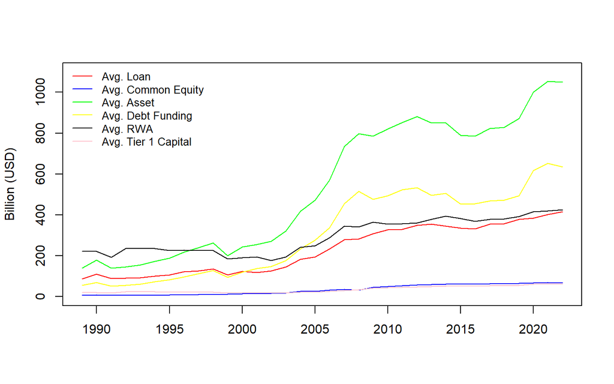

```r
# Overview of the key elements of our data


dataWork <- as.data.frame(data)
# dataWork$year <- as.Date(dataWork$year,format = '%Y')
# dataWork$year <- format(as.Date(dataWork$year), format = "%Y")

graph <- dataWork %>%
  group_by(year) %>%
  summarise(
    totalLoan=mean(TLoan/1000),
    totalCE=mean(TCE/1000),
    totalASs=mean(TA/1000),
    totalfun=mean(TFunding/1000),
    totalRwa=mean(RWA/1000),
    totalTier1=mean(TierCap/1000),

  )


plot(
  x=graph$year,
  y=graph$totalLoan,
  type='l',
  xlab = "",
  ylab = "Billion (USD)",
  # main = 'Major Financial Overview (1989 - 2022)',
  col='red',
  ylim=c(0,1100)
)

lines(
  x=graph$year,
  y=graph$totalCE,
  col='blue'
)
lines(
  x=graph$year,
  y=graph$totalASs,
  col='green'
)
lines(
  x=graph$year,
  y=graph$totalfun,
  col='yellow'
)
lines(
  x=graph$year,
  y=graph$totalRwa,
  col='black'
)
lines(
  x=graph$year,
  y=graph$totalTier1,
  col='pink'
)

legend("topleft", # orientation of legend
       legend = c('Avg. Loan','Avg. Common Equity', 'Avg. Asset', 'Avg. Debt Funding','Avg. RWA','Avg. Tier 1 Capital' ),
       bg = "NA", # no background
       bty = "n", # no box around legend
       cex = 0.85, # character expansion factor, 0.5 = half of the standard size
       col = c("red","blue",'green','yellow', 'black','pink'), # colour of the lines
       lty = 1)
```

### Graphs for leverage ratio

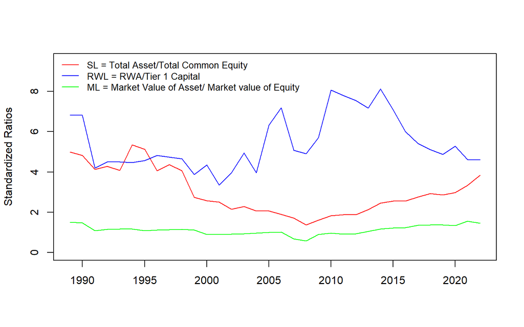

```r
graph_leverage <- dataWork %>%
  group_by(year) %>%
  summarise(
    StandardL=mean(TA_TE)/sd(TA_TE),
    RiskL=mean(RWA_TierCap)/sd(RWA_TierCap),
    MarketL=mean(FVA_TCE)/sd(FVA_TCE)
  )


plot(
  x=graph_leverage$year,
  y=graph_leverage$StandardL,
  type='l',
  xlab = "",
  ylab = "Standardized Ratios",
  main = '',
  col='red',
  ylim=c(0,9.5)
)

lines(
  x=graph_leverage$year,
  y=graph_leverage$RiskL,
  col='blue'
)
lines(
  x=graph_leverage$year,
  y=graph_leverage$MarketL,
  col='green'
)


legend("topleft", # orientation of legend
       legend = c('SL = Total Asset/Total Common Equity', 'RWL = RWA/Tier 1 Capital',
                  'ML = Market Value of Asset/ Market value of Equity'),
       bg = "NA", # no background
       bty = "n", # no box around legend
       cex = 0.85, # character expansion factor, 0.5 = half of the standard size
       col = c("red","blue",'green'), # colour of the lines
       lty = 1)
```